# Dissever Tutorial

Malone, B. and Roudier, P.

2018-04-20

```r
library(dissever)

library(raster)
library(viridis)
library(dplyr)
library(magrittr)
```

Here is the coarse model to dissever:

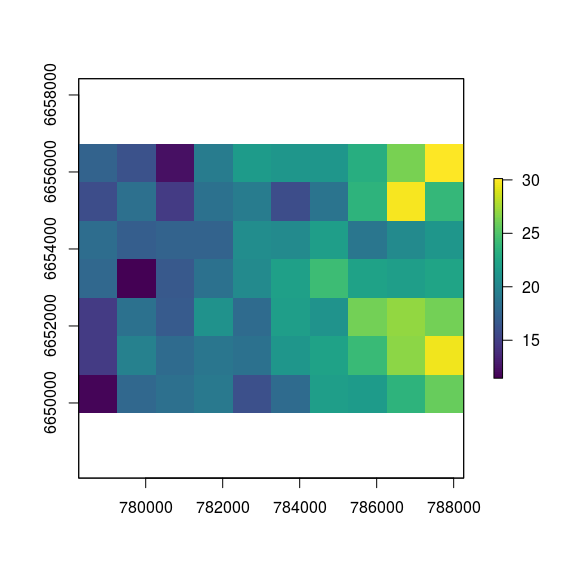

```r
plot(edgeroi$carbon, col = viridis(100))
```

and here are the covariates that will be used for the disseveration:

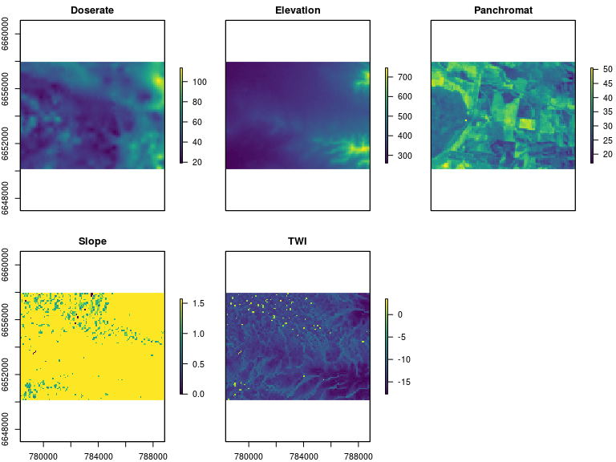

```r
plot(edgeroi$predictors, col = viridis(100))
```

## Example

It is simple to switch between regression methods using the `method` option of `dissever`.

But first let’s setup some parameters:

```r
min_iter <- 5 # Minimum number of iterations
max_iter <- 10 # Maximum number of iterations
p_train <- 0.025 # Subsampling of the initial data
```

We can then launch the 4 different disseveration procedures:

```r
# Random Forest
res_rf <- dissever(
    coarse = edgeroi$carbon, # stack of fine resolution covariates
    fine = edgeroi$predictors, # coarse resolution raster
    method = "rf", # regression method used for disseveration
    p = p_train, # proportion of pixels sampled for training regression model
    min_iter = min_iter, # minimum iterations
    max_iter = max_iter # maximum iterations
  )

# Cubist
res_cubist <- dissever(
  coarse = edgeroi$carbon,
  fine = edgeroi$predictors,
  method = "cubist",
  p = p_train,
  min_iter = min_iter,
  max_iter = max_iter
)

# GAM
res_gam <- dissever(
  coarse = edgeroi$carbon,
  fine = edgeroi$predictors,
  method = "gamSpline",
  p = p_train,
  min_iter = min_iter,
  max_iter = max_iter
)

# Linear model
res_lm <- dissever(
  coarse = edgeroi$carbon,
  fine = edgeroi$predictors,
  method = "lm",
  p = p_train,
  min_iter = min_iter,
  max_iter = max_iter
)
```

# Analysing the results

The object returned by `dissever` is an object of class `dissever`. It’s basically a `list` with 3 elements: * `fit`: a `train` object storing the regression model used in the final disseveration * `map`: a `RasterLayer` object storing the dissevered map * `perf`: a `data.frame` object storing the evolution of the RMSE (and confidence intervals) with the disseveration iterations.

The `dissever` result has a `plot` function that can plot either the map or the performance results, depending on the `type` option.

## Maps

Below are the dissevered maps for all 4 regression methods:

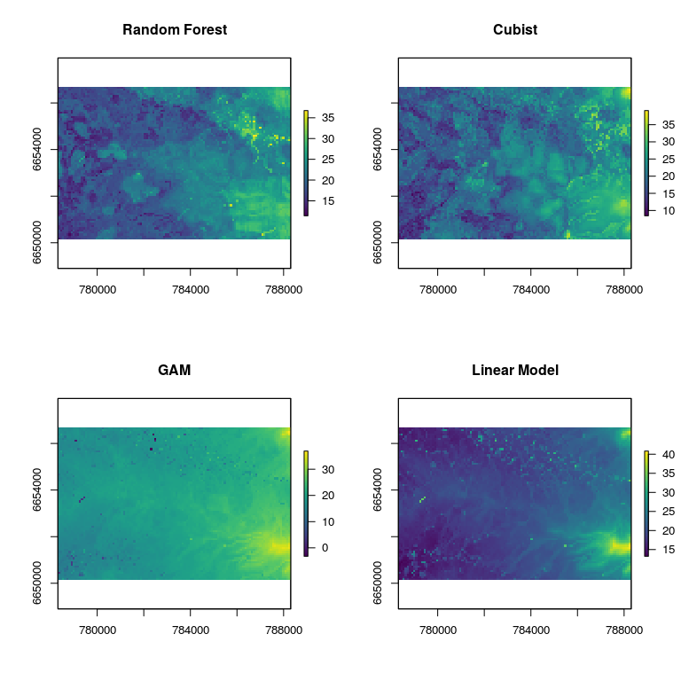

```r
# Plotting maps
par(mfrow = c(2, 2))
plot(res_rf, type = 'map', main = "Random Forest")
plot(res_cubist, type = 'map', main = "Cubist")
plot(res_gam, type = 'map', main = "GAM")
plot(res_lm, type = 'map', main = "Linear Model")
```

## Convergence

We can also analyse and plot the optimisation of the dissevering model:

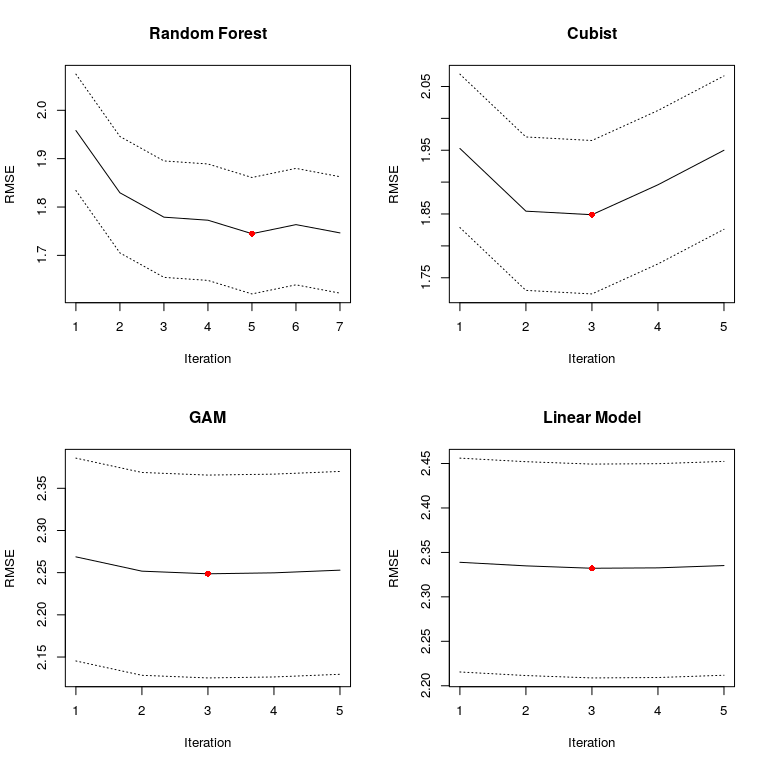

```r
# Plot performance
par(mfrow = c(2, 2))
plot(res_rf, type = 'perf', main = "Random Forest")
plot(res_cubist, type = 'perf', main = "Cubist")
plot(res_gam, type = 'perf', main = "GAM")
plot(res_lm, type = 'perf', main = "Linear Model")
```

## Performance of the regression

The tools provided by the `caret` package can also be leveraged, e.g. to plot the observed vs. predicted values:

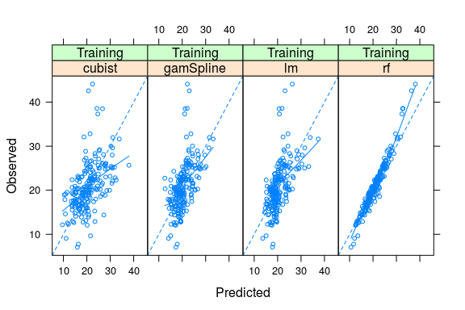

```r
# Plot preds vs obs
preds <- extractPrediction(list(res_rf$fit, res_cubist$fit, res_gam$fit, res_lm$fit))
plotObsVsPred(preds)
```

```r
# Compare models
perf <- preds %>%
  group_by(model, dataType) %>%
  summarise(
    rsq = cor(obs, pred)^2,
    rmse = sqrt(mean((pred - obs)^2))
  )
perf
```

```
## # A tibble: 4 x 4
## # Groups:   model [?]
##   model     dataType   rsq  rmse
##   <fct>     <fct>    <dbl> <dbl>
## 1 cubist    Training 0.260  5.35
## 2 gamSpline Training 0.312  4.66
## 3 lm        Training 0.349  4.52
## 4 rf        Training 0.951  1.53
```

# Ensemble approach

```r
# We can weight results with Rsquared
w <- perf$rsq / sum(perf$rsq)

# Make stack of weighted predictions and compute sum
l_maps <- list(res_cubist$map, res_gam$map, res_lm$map, res_rf$map)
ens <- lapply(1:4, function(x) l_maps[[x]] * w[x]) %>%
  stack %>%
  sum
```

Ensemble modelling seem to work better when the models are not too correlated – i.e. when they capture different facets of the data:

```r
s_res <- stack(l_maps)
names(s_res) <- c('Cubist', 'GAM', 'Linear Model', 'Random Forest')
s_res %>%
  as.data.frame %>%
  na.exclude %>%
  cor
```

```
##                  Cubist       GAM Linear.Model Random.Forest
## Cubist        1.0000000 0.7725831    0.7027710     0.7421504
## GAM           0.7725831 1.0000000    0.8880034     0.7831751
## Linear.Model  0.7027710 0.8880034    1.0000000     0.8094299
## Random.Forest 0.7421504 0.7831751    0.8094299     1.0000000
```

Here is the resulting map:

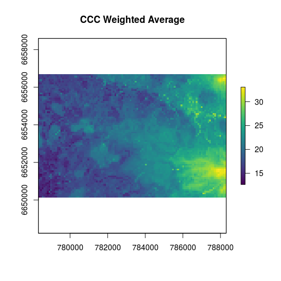

```r
# Plot result
plot(ens, col = viridis(100), main = "CCC Weighted Average")
```